# Homework Assignment #3

Author

Liane Chen

Published

February 3, 2024

```r
##~~~~~~~~~~~~~~~~~~~~~~~~~~~~~~~~~~~~~~~~~~~~~~~~~~~~~~~~~~~~~~~~~~~~~~~~~~~~~~
##                                wrangle data                              ----
##~~~~~~~~~~~~~~~~~~~~~~~~~~~~~~~~~~~~~~~~~~~~~~~~~~~~~~~~~~~~~~~~~~~~~~~~~~~~~~

wildfire <- janitor::clean_names(wildfire_original) %>%

  #replace the numeric '-99999' code with NA values in order to drop NAs
  replace_with_na(replace = list(-99999)) %>%

  #select columns we are interested in
  select(incid_name, incid_type, burn_bnd_ac, ig_date, geometry) %>%

  #remove NA observations
  drop_na()
```

##Which option do you plan to pursue? Restate your question(s). Has this changed at all since HW #1? If yes, how so?

```
ANSWER: I plan to puruse option 1, where I will have one question that each of
the three visualizations works to answer, where each visualization is meant to
reach / serve a different target audience and purpose. To restate, my question
is: "How have wildfires in the US changed over time?" Yes, this question has
changed, since my first question in HW#1 relied on incorporating a dataset that
turned out to be a bust and had very little information in it to extract anything
meaningful. This one is more fun though because I can plot data over time and
that is intuitive to me.
```

##Explain which variables from your data set(s) you will use to answer your question(s).

```
ANSWER: The variables I will use to answer my question include 'ignition date',
'burned area (acres)', and 'incident types'. The reason why I would like to look
at these variables is because I think these will provide enough flexibility to
include detailed info and enough large groupings to summarize.
```

##Find at least two data visualizations that you could (potentially) borrow / adapt pieces from. Link to them or download and embed them into your .qmd file, and explain which elements you might borrow (e.g. the graphic form, legend design, layout, etc.).

```
ANSWER: I like how Meghan annotates her plot with further context, while keeping
the overall aethetic pretty clean in her hockey plot: https://meghan.rbind.io/blog/2022-02-22-increasing-the-flexibility-and-robustness-
of-plots-in-ggplot2/ .I may borrow how she annotates her plot in the lower right
corner of the plot.

Another plot that I like is Cedric's historical mobile subscriptions plot here: https://raw.githubusercontent.com/Z3tt/TidyTuesday/main/plots/2020_46/2020_46_
HistoricalPhones.png. I am thinking that perhaps this will be a good crossover
for the histortical wildfire plots that I am trying to make. Specifically, I
like his layout with the world proportions on the right, which I think will work
nicely for the incident types, perhaps?
```

##Hand-draw your anticipated three visualizations (option 1) or infographic (option 2). Take a photo of your drawing and embed it in your rendered .qmd file – note that these are not exploratory visualizations, but rather your plan for your final visualizations that you will eventually polish and submit with HW #4.

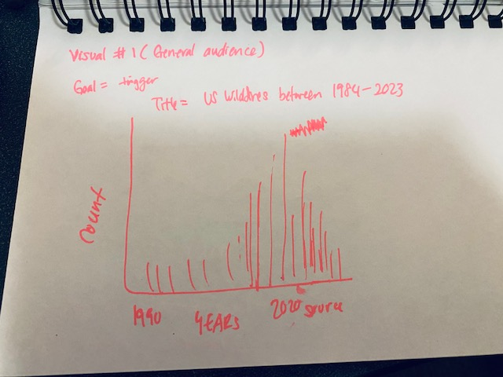

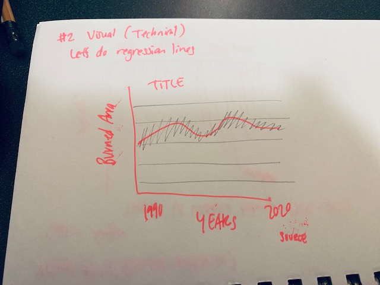

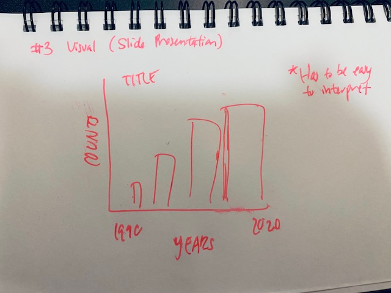

##Mock up your visualizations using code.

```r
#data exploration and clean up
wildfire <- unique(wildfire)

large_wildfire <- filter(wildfire, burn_bnd_ac >= 1000)

large_wildfire <- na.omit(large_wildfire)

summary(large_wildfire)
```

```
  incid_name         incid_type         burn_bnd_ac         ig_date
 Length:25657       Length:25657       Min.   :   1000   Min.   :1984-01-26
 Class :character   Class :character   1st Qu.:   1481   1st Qu.:1999-08-14
 Mode  :character   Mode  :character   Median :   2381   Median :2008-03-24
                                       Mean   :   8194   Mean   :2006-08-23
                                       3rd Qu.:   5100   3rd Qu.:2015-04-22
                                       Max.   :1068802   Max.   :2022-12-02
          geometry
 MULTIPOLYGON :25657
 epsg:4269    :    0
 +proj=long...:    0
```

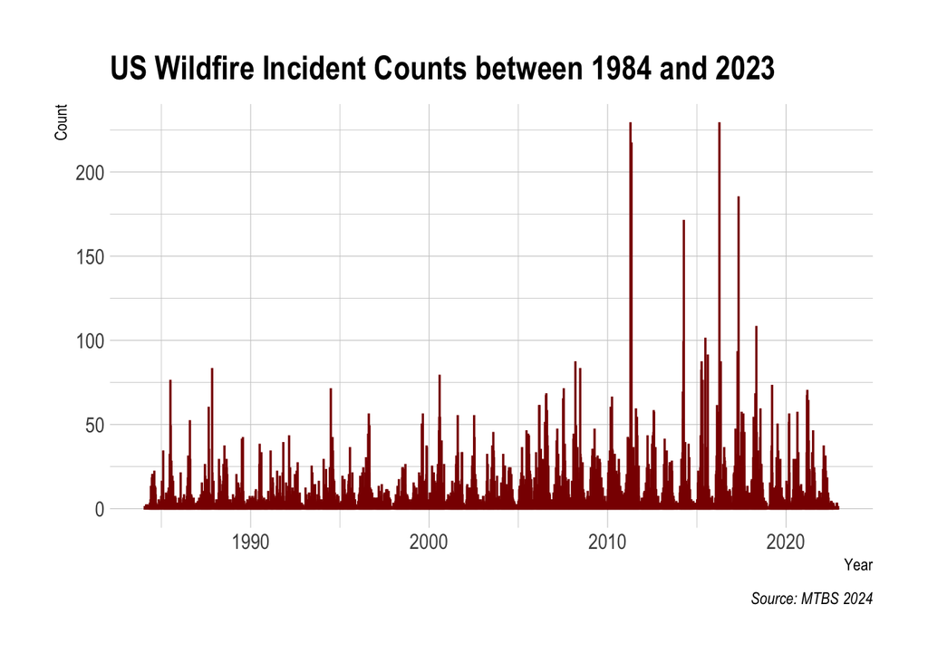

```r
large_wildfire %>%
  ggplot( aes(x=ig_date)) +
    geom_histogram(binwidth = 7, fill = "darkred", color = "darkred", alpha = 0.5) +
  labs(x = "Year", y = "Count", title = "US Wildfire Incident Counts between 1984 and 2023", caption = "Source: MTBS 2024") +
  theme_ipsum()
```

###Visualization (2) to be included in a report This plot includes more statistical information (regressionline) in a streamlined presentation for a technical audience.

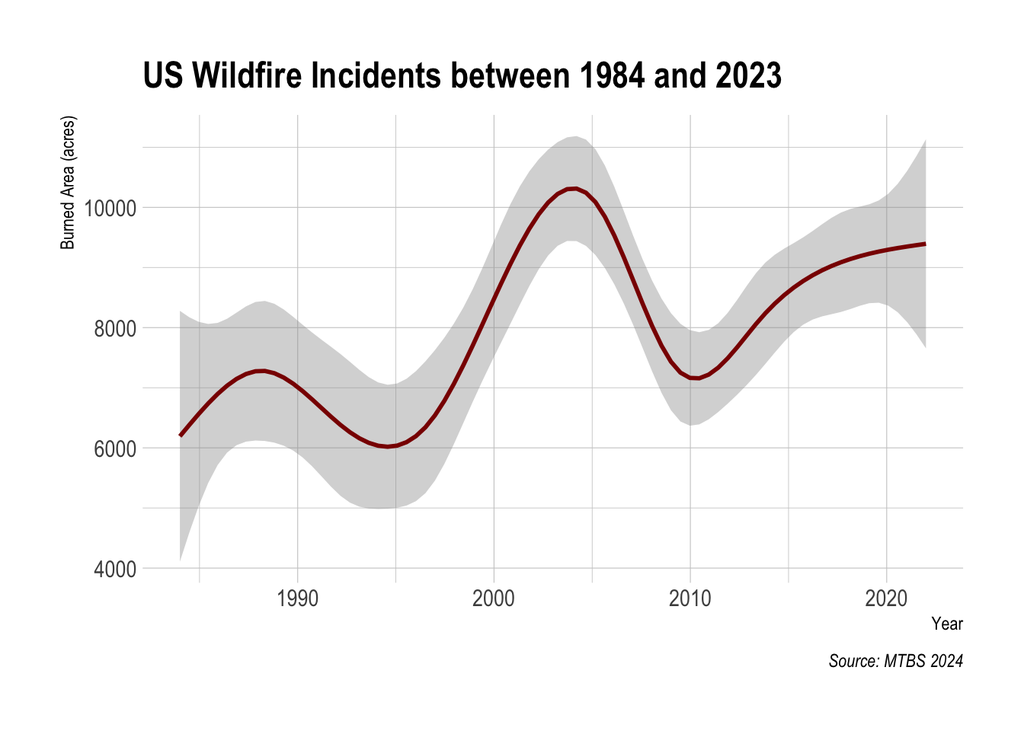

```r
# add year column to data frame
large_wildfire$year <- format(large_wildfire$ig_date, "%Y")

large_wildfire <- transform(large_wildfire, year = as.numeric(year))

large_wildfire %>%
  ggplot(aes(x = year, y = burn_bnd_ac, fill = burn_bnd_ac)) +
  #geom_area(position = "stack", fill="darkred") +
  geom_smooth(color="darkred") +
  scale_fill_continuous(guide = "none") +
  labs(title = "US Wildfire Incidents between 1984 and 2023",
       x = "Year",
       y = "Burned Area (acres)",
       caption = "Source: MTBS 2024") +
  theme_ipsum()
```

###Visualization (3) for inclusion in a presentation Next, we will group the date into decades, so to make the information easier to digest for the audience with a shorter amount of time to process.

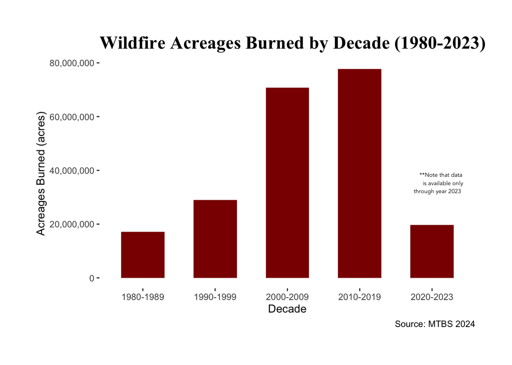

```r
#add a year column
wildfire$year <- year(wildfire$ig_date)

#add a column that groups dates into decades
wildfire_decade <- mutate(wildfire,
                          decade = case_when(
                          year %in% 1980:1989 ~ "1980-1989",
                          year %in% 2000:2009 ~ "2000-2009",
                          year %in% 1990:1999 ~ "1990-1999",
                          year %in% 2000:2009 ~ "2000-2009",
                          year %in% 2010:2019 ~ "2010-2019",
                          year %in% 2020:2029 ~ "2020-2023",
                                 TRUE ~ NA_character_
                          ))

#remove NAs
wildfire_decade <- group_by(wildfire_decade, decade, na.rm=TRUE)

#plot
ggplot(data=wildfire_decade, width = 4, height = 4) +
  geom_col(mapping = aes(x=decade, y=burn_bnd_ac), fill="darkred", width=0.6) +
  scale_y_continuous(name ="Acreages Burned (acres)", labels = scales::comma) +
  labs(caption = "Source: MTBS 2024") +
  xlab("Decade") +
  annotate("text", x=Inf, y=Inf, hjust=1.3, vjust=6.5, size=2,
           label = "**Note that data\nis available only\nthrough year 2023", family = "Avenir") +
  ggtitle("Wildfire Acreages Burned by Decade (1980-2023)") +
  theme(plot.title = element_text(size = 18, family="Times New Roman", face = "bold", margin = margin(b = 6)),
        panel.background = element_rect(fill = "white"), plot.margin = unit(c(0.5, 0.5, 0.5, 0.5), "inches"))
```

##What challenges did you encounter or anticipate encountering as you continue to build / iterate on your visualizations in R?

```
Some of the other plots I tried including using the spatial data to show
geographical data, but that was too spread apart, and creating stacked stream
graphs with the decades data, but the class types did not work. I want to
continue building out annotations and labels for these current graphs, and
anticipate needing to spend time on figuring out the positioning of the text.
```

##What ggplot extension tools / packages do you need to use to build your visualizations? Are there any that we haven’t covered in class that you’ll be learning how to use for your visualizations?

```
I used the hrbr package and found some themes that I think are now my favorites,
in replacement of theme_minimal. For the next iteration, I want to work more with
gghighlight and see if I can call out the top three major fires and add text.
```

##What feedback do you need from the instructional team and / or your peers to ensure that your intended message is clear?

```
I'm having trouble using some of the fill= syntax when there are three variables
and could use more tips on how to get the plots to actually plot when this
happens. Usually it is two numeric and one categorical.
```